# Teknik Sampling

UAS Nomor 4

Vanessa Supit

May 27, 2021

[figure not shown]

Email : vanessasupit0910@gmail.com  
RPubs : https://rpubs.com/vanessasupit/  
Department : [Business Statistics](https://matanauniversity.ac.id/?ly=academic&c=sb)  
Address : ARA Center, Matana University Tower  
Jl. CBD Barat Kav, RT.1, Curug Sangereng, Kelapa Dua, Tangerang, Banten 15810.

Berikut merupakan library-library yang akan digunakan dalam pemodelan spasial

```r
library(rgdal)
library(raster)
library(spdep)
library(sp)
library(raster)
library(rgeos)
library(rspatial)
library(latticeExtra)
library(RColorBrewer)
library(spatialreg)
library(DT)
```

# 1 Input Data

Link untuk file bisa diambil [di sini](https://github.com/VanessaSupit/TSSpatialModel)

```r
data = readOGR(dsn = "data", layer = "NCVACO")
```

-Daftar variabel dataset

```r
names(data)
```

```
##  [1] "GEO_ID"     "STATE"      "COUNTY"     "NAME"       "LSAD"
##  [6] "CENSUSAREA" "FIPS2"      "Lon"        "Lat"        "FIPS"
## [11] "qtystores"  "SALESPC"    "PCI"        "COMM15OVP"  "COLLENRP"
## [16] "SOMECOLLP"  "ARMEDP"     "NONWHITEP"  "UNEMPP"     "ENTRECP"
## [21] "PUBASSTP"   "POVPOPP"    "URBANP"     "FOREIGNBP"  "BAPTISTSP"
## [26] "ADHERENTSP" "BKGRTOMIX"  "COUNTMXBV"  "MXBVSQM"    "BKGRTOABC"
## [31] "MXBVPPOP18" "DUI1802"    "FVPTHH02"   "DC"         "GA"
## [36] "KY"         "MD"         "SC"         "TN"         "WV"
## [41] "VA"         "AREALANDSQ" "COUNTBKGR"  "TOTALPOP"   "POP18OV"
## [46] "LABFORCE"   "HHOLDS"     "POP25OV"    "POP16OV"
```

Dataset ini adalah beberapa data dari beberapa penelitian yang dilakukan Mark Burkey tentang permintaan minuman keras menggunakan data dari sekitar tahun 2003. Secara khusus, dia melihat negara bagian Virginia dan Carolina Utara. Dataset ini terkait dengan, tetapi tidak sama dengan data yang digunakan untuk hibah NIH dan diterbitkan dalam makalah:

> [Burkey, Mark L. Geographic Access and Demand in the Market for Alcohol. The Review of Regional Studies, 40(2), Fall 2010, 159-179](https://ideas.repec.org/p/pra/mprapa/36913.html)

Unit analisis: kabupaten di Virginia dan Carolina Utara

Deskripsi Variabel:

- `Lon Lat` Bujur dan Lintang dari County Centroid
- `FIPS` Kode FIPS untuk Wilayah (Standar Pemrosesan Informasi Federal)
- `qtystores` #Toko Minuman Keras di County
- `SALESPC` Penjualan Minuman Keras per kapita per tahun, $
- `PCI` Pendapatan per kapita
- `COMM15OVP` % bepergian selama 15 menit ke kantor
- `COLLENRP` % orang yang saat ini terdaftar di perguruan tinggi
- `SOMECOLLP` % orang yang kuliah atau berpendidikan lebih tinggi
- `ARMEDP` % di angkatan bersenjata
- `NONWHITEP` % bukan kulit putih
- `UNEMPP` % pengangguran
- `ENTRECP` % dipekerjakan di bidang hiburan atau rekreasi (perwakilan untuk bidang pariwisata)
- `PUBASSTP` % tentang bantuan publik
- `POVPOPP` % dalam kemiskinan
- `URBANP` % tinggal di daerah perkotaan
- `FOREIGNBP` % lahir di luar negeri
- `BAPTISTSP` % baptis selatan (secara historis anti-alkohol)
- `ADHERENTSP` % penganut agama apapun
- `BKGRTOMIX` wtd. jarak rata-rata dari kelompok blok ke bar terdekat yang menjual minuman keras
- `COUNTMXBV` hitungan bar yang menjual minuman keras
- `MXBVSQM` bar per mil persegi
- `BKGRTOABC` jarak dari grup blok ke outlet ritel minuman keras terdekat (“toko ABC”)
- `MXBVPPOP18OV` Bar per 1.000? orang berusia 18 tahun ke atas
- `DUI1802` Penangkapan DUI per 1.000 orang 18+
- `FVPTHH02` Pelanggaran terhadap keluarga dan anak (kekerasan dalam rumah tangga) per 1.000 rumah tangga
- DC GA KY MD SC TN WV VA Variabel tiruan untuk negara bagian yang berbatasan dengan negara bagian lain
- `AREALANDSQMI` Luas wilayah
- `COUNTBKGR` jumlah kelompok blok di daerah
- `TOTALPOP` Penduduk daerah
- `POP18OV` orang berusia 18+ di daerah
- `LABFORCE` jumlah angkatan kerja di daerah
- `HHOLDS` # rumah tangga di daerah
- `POP25OV` Pop 25+ di daerah
- `POP16OV` Pop 16+ di daerah

# 2 Pemetaan Distribusi Spasial

Sebelumnya kita akan mentransformasi struktur variabel *PCI* (Pendapatan per kapita) dari faktor ke numerik

```r
data$PCI <- as.numeric(levels(data$PCI))[data$PCI]
```

Sekarang kita akan memvisualisasikan penjualan minuman keras per kapita

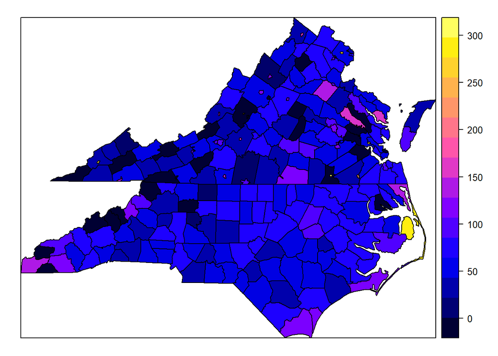

```r
spplot(data, "SALESPC")
```

Dari hasil visualisasi di atas kita bisa melihat bahwa rata-rata penjualan minuman keras di tiap daerah berkisar di angka 50-150. Namun ada satu daerah dengan penjualan kapita yang sangat tinggi yang mencapai300 per kapita, yaitu area berwarna kuning.

# 3 Pemodelan Regresi Spasial

Di bagian sini kita akan membangun model linier untuk data kita. Model spasial secara global terdiri dari:

- SEM: $y=XB+u$
- SAR: $y=\rho Wy+XB+\varepsilon$
- SARMA: $y=\rho Wy+XB+u$

Sebelum memulai pemodelan kita perlu membuat pemberat dengan fungsi berikut

```r
queen.nb <- poly2nb(data)             # Menciptakan relasi
listw <- nb2listw(queen.nb)           # Mengkonversi nb ke listw
```

Selanjutnya kita akan membuat persamaan model linier kita

```r
lm <-DUI1802 ~ SALESPC + COLLENRP + BKGRTOABC + BAPTISTSP + BKGRTOMIX + ENTRECP
```

## 3.1 Model SEM

```r
reg1 <- errorsarlm(lm, data=data, listw)
summary(reg1)
```

```
##
## Call:errorsarlm(formula = lm, data = data, listw = listw)
##
## Residuals:
##      Min       1Q   Median       3Q      Max
## -7.21199 -2.66820 -0.85841  1.57794 25.85910
##
## Type: error
## Coefficients: (asymptotic standard errors)
##               Estimate Std. Error z value  Pr(>|z|)
## (Intercept)  5.1218025  1.4443139  3.5462 0.0003909
## SALESPC      0.0111587  0.0076284  1.4628 0.1435286
## COLLENRP     0.0533827  0.0617209  0.8649 0.3870915
## BKGRTOABC    0.1533586  0.1454500  1.0544 0.2917121
## BAPTISTSP    0.0326804  0.0394447  0.8285 0.4073797
## BKGRTOMIX   -0.0232354  0.0832068 -0.2792 0.7800541
## ENTRECP      0.1067644  0.1449288  0.7367 0.4613242
##
## Lambda: 0.40342, LR test value: 20.075, p-value: 7.4467e-06
## Asymptotic standard error: 0.075449
##     z-value: 5.347, p-value: 8.9438e-08
## Wald statistic: 28.59, p-value: 8.9438e-08
##
## Log likelihood: -694.1478 for error model
## ML residual variance (sigma squared): 21.247, (sigma: 4.6095)
## Number of observations: 234
## Number of parameters estimated: 9
## AIC: 1406.3, (AIC for lm: 1424.4)
```

## 3.2 Model SAR

```r
reg2 <- lagsarlm(lm, data = data, listw)
summary(reg2)
```

```
##
## Call:lagsarlm(formula = lm, data = data, listw = listw)
##
## Residuals:
##      Min       1Q   Median       3Q      Max
## -7.18539 -2.59660 -0.77605  1.61369 25.93228
##
## Type: lag
## Coefficients: (asymptotic standard errors)
##              Estimate Std. Error z value Pr(>|z|)
## (Intercept) 1.5421139  1.3012975  1.1851  0.23599
## SALESPC     0.0138185  0.0077171  1.7906  0.07335
## COLLENRP    0.0327744  0.0603469  0.5431  0.58706
## BKGRTOABC   0.1164671  0.1358375  0.8574  0.39122
## BAPTISTSP   0.0392792  0.0332872  1.1800  0.23800
## BKGRTOMIX   0.0092150  0.0700728  0.1315  0.89538
## ENTRECP     0.1532086  0.1359122  1.1273  0.25963
##
## Rho: 0.39828, LR test value: 22.924, p-value: 1.6858e-06
## Asymptotic standard error: 0.07512
##     z-value: 5.3019, p-value: 1.1459e-07
## Wald statistic: 28.11, p-value: 1.1459e-07
##
## Log likelihood: -692.7235 for lag model
## ML residual variance (sigma squared): 21.012, (sigma: 4.5839)
## Number of observations: 234
## Number of parameters estimated: 9
## AIC: 1403.4, (AIC for lm: 1424.4)
## LM test for residual autocorrelation
## test value: 13.047, p-value: 0.0003037
```

## 3.3 Model SARMA

```r
reg3 <- sacsarlm(lm,data = data, listw)
summary(reg3)
```

```
##
## Call:sacsarlm(formula = lm, data = data, listw = listw)
##
## Residuals:
##      Min       1Q   Median       3Q      Max
## -7.01945 -2.34197 -0.78281  1.41007 23.48056
##
## Type: sac
## Coefficients: (asymptotic standard errors)
##               Estimate Std. Error z value Pr(>|z|)
## (Intercept) -0.8353870  0.9351383 -0.8933  0.37168
## SALESPC      0.0171848  0.0067612  2.5417  0.01103
## COLLENRP     0.0138969  0.0505268  0.2750  0.78328
## BKGRTOABC    0.1404632  0.1045255  1.3438  0.17901
## BAPTISTSP    0.0211294  0.0225887  0.9354  0.34958
## BKGRTOMIX   -0.0214055  0.0491538 -0.4355  0.66321
## ENTRECP      0.1409664  0.1061888  1.3275  0.18434
##
## Rho: 0.74152
## Asymptotic standard error: 0.069065
##     z-value: 10.737, p-value: < 2.22e-16
## Lambda: -0.60359
## Asymptotic standard error: 0.13376
##     z-value: -4.5125, p-value: 6.4082e-06
##
## LR test value: 32.473, p-value: 8.8832e-08
##
## Log likelihood: -687.9487 for sac model
## ML residual variance (sigma squared): 16.534, (sigma: 4.0662)
## Number of observations: 234
## Number of parameters estimated: 10
## AIC: 1395.9, (AIC for lm: 1424.4)
```